# R and Hadoop

## R and Hadoop

### Revolution Analytics

##### Antonio Piccolboni

operating system of the cloud – focus is scalability – different from HPC – storage, fault tolerance built in, programming model

[figure not shown]

[figure not shown]

[r4stats](http://r4stats.com/popularity) – Google from niche to main language – oreilly hot language – SAS and mathematica compatibility

[figure not shown]

[figure not shown]

hadoop brings horizontal scalability – r sophisticated analytics – combination could be powerful

##

- rhdfs
- rhbase
- *rmr2*

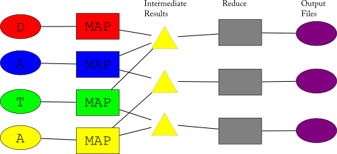

##

```r
    library(rmr2)

    mapreduce(input, ...)
```

why RHadoop for the R dev – The data is in Hadoop – The biggest cluster is Hadoop Just a library Not a special run-time Not a different language Not a special purpose language Incrementally port your code Use all packages

##

```r
    sapply(data, function)

    mapreduce(big.data, map = function)
```

Very R-like, building on the functional characteristics of R Upholds scope rules

|  | *Hive, Pig* |
| --- | --- |
| **Rmr**, Rhipe, Dumbo, Pydoop, Hadoopy | Cascalog, Scalding, Scrunch |
| Java, C++ | Cascading, Crunch |

Much simpler than writing Java Not as simple as Hive, Pig at what they do, but more general, a real language Great for prototyping, can transition to production – optimize instead of rewriting! Lower risk, always executable.

##

```python
#!/usr/bin/python
import sys
from math import fabs
from org.apache.pig.scripting import Pig

filename = "student.txt"
k = 4
tolerance = 0.01

MAX_SCORE = 4
MIN_SCORE = 0
MAX_ITERATION = 100

# initial centroid, equally divide the space
initial_centroids = ""
last_centroids = [None] * k
for i in range(k):
  last_centroids[i] = MIN_SCORE + float(i)/k*(MAX_SCORE-MIN_SCORE)
  initial_centroids = initial_centroids + str(last_centroids[i])
  if i!=k-1:
    initial_centroids = initial_centroids + ":"

P = Pig.compile("""register udf.jar
          DEFINE find_centroid FindCentroid('$centroids');
          raw = load 'student.txt' as (name:chararray, age:int, gpa:double);
          centroided = foreach raw generate gpa, find_centroid(gpa) as centroid;
          grouped = group centroided by centroid;
          result = foreach grouped generate group, AVG(centroided.gpa);
          store result into 'output';
        """)

converged = False
iter_num = 0
while iter_num<MAX_ITERATION:
  Q = P.bind({'centroids':initial_centroids})
  results = Q.runSingle()
```

##

```python
  if results.isSuccessful() == "FAILED":
    raise "Pig job failed"
  iter = results.result("result").iterator()
  centroids = [None] * k
  distance_move = 0
  # get new centroid of this iteration, caculate the moving distance with last iteration
  for i in range(k):
    tuple = iter.next()
    centroids[i] = float(str(tuple.get(1)))
    distance_move = distance_move + fabs(last_centroids[i]-centroids[i])
  distance_move = distance_move / k;
  Pig.fs("rmr output")
  print("iteration " + str(iter_num))
  print("average distance moved: " + str(distance_move))
  if distance_move<tolerance:
    sys.stdout.write("k-means converged at centroids: [")
    sys.stdout.write(",".join(str(v) for v in centroids))
    sys.stdout.write("]\n")
    converged = True
    break
  last_centroids = centroids[:]
  initial_centroids = ""
  for i in range(k):
    initial_centroids = initial_centroids + str(last_centroids[i])
    if i!=k-1:
      initial_centroids = initial_centroids + ":"
  iter_num += 1

if not converged:
  print("not converge after " + str(iter_num) + " iterations")
  sys.stdout.write("last centroids: [")
  sys.stdout.write(",".join(str(v) for v in last_centroids))
  sys.stdout.write("]\n")
```

##

```java
import java.io.IOException;

import org.apache.pig.EvalFunc;
import org.apache.pig.data.Tuple;


public class FindCentroid extends EvalFunc<Double> {
  double[] centroids;
  public FindCentroid(String initialCentroid) {
    String[] centroidStrings = initialCentroid.split(":");
    centroids = new double[centroidStrings.length];
    for (int i=0;i<centroidStrings.length;i++)
      centroids[i] = Double.parseDouble(centroidStrings[i]);
  }
  @Override
  public Double exec(Tuple input) throws IOException {
    double min_distance = Double.MAX_VALUE;
    double closest_centroid = 0;
    for (double centroid : centroids) {
      double distance = Math.abs(centroid - (Double)input.get(0));
      if (distance < min_distance) {
        min_distance = distance;
        closest_centroid = centroid;
      }
    }
    return closest_centroid;
  }

}
```

# A brief history of rmr

# Read and Write

# Identity

```r
  mapreduce(
    input,
    map = function(k, v) keyval(k, v))
```

# Filter

# Select

# Sum

# Group and Aggregate

```r
  input.ga =
    to.dfs(
      cbind(
        1:input.size,
        rnorm(input.size)))
```

```r
  group = function(x) x%%10
  aggregate = function(x) sum(x)
```

```r
  mapreduce(
    input.ga,
      map =
        function(k, v)
          keyval(group(v[,1]), v[,2]),
      reduce =
        function(k, vv)
          keyval(k, aggregate(vv)),
      combine = TRUE)
```

# Live demo

```
shrink = function(ct) {
  ct = ddply(ct,c("x", "y"), .fun= function(x) c(Freq = sum(x$Freq)))
  ct[ct$Freq > 0, ]}
```

```
from.dfs(mapreduce(DS.big, map = function(k,v) keyval(1,as.data.frame(table(v))), reduce = function(k,vv) keyval(1, shrink(vv)), combine=T))
```

# K-means

##

```r
    dist.fun =
      function(C, P) {
        apply(
          C,
          1,
          function(x)
            colSums((t(P) - x)^2))}
```

##

```r
    kmeans.map =
      function(., P) {
        nearest = {
          if(is.null(C))
            sample(
              1:num.clusters,
              nrow(P),
              replace = T)
          else {
            D = dist.fun(C, P)
            nearest = max.col(-D)}}
        if(!(combine || in.memory.combine))
          keyval(nearest, P)
        else
          keyval(nearest, cbind(1, P))}
```

##

```r
    kmeans.reduce = {
      if (!(combine || in.memory.combine) )
        function(., P)
          t(as.matrix(apply(P, 2, mean)))
      else
        function(k, P)
          keyval(
            k,
            t(as.matrix(apply(P, 2, sum))))}
```

##

```r
kmeans.mr =
  function(
    P,
    num.clusters,
    num.iter,
    combine,
    in.memory.combine) {
```

##

```r
    C = NULL
    for(i in 1:num.iter ) {
      C =
        values(
          from.dfs(
            mapreduce(
              P,
              map = kmeans.map,
              reduce = kmeans.reduce)))
      if(combine || in.memory.combine)
        C = C[, -1]/C[, 1]
```

##

```r
      if(nrow(C) < num.clusters) {
        C =
          rbind(
            C,
            matrix(
              rnorm(
                (num.clusters -
                   nrow(C)) * nrow(C)),
              ncol = nrow(C)) %*% C) }}
        C}
```

##

```r
  P =
    do.call(
      rbind,
      rep(
        list(
          matrix(
            rnorm(10, sd = 10),
            ncol=2)),
        20)) +
    matrix(rnorm(200), ncol =2)
```

##

```r
    kmeans.mr(
      to.dfs(P),
      num.clusters = 12,
      num.iter = 5,
      combine = FALSE,
      in.memory.combine = FALSE)
```

Other features: easy composition of jobs, joins, local modes, combine

##

#### Revolution Analytics

### rhadoop@revolutionanalytics.com

#### Antonio Piccolboni

### antonio@piccolboni.info